# Risk Factor Analysis

## Outcome Variable

**Outcome Variable:** ever_co

## Predictor Variables

**Intervention Variable:** birthlen

**Adjustment Set:**

- arm
- sex
- W_mage
- meducyrs
- feducyrs
- vagbrth
- single
- brthmon
- W_parity
- delta_W_mage
- delta_meducyrs
- delta_feducyrs
- delta_vagbrth
- delta_single
- delta_brthmon
- delta_W_parity

## Stratifying Variables

The analysis was stratified on these variable(s):

- agecat
- studyid
- country

## Data Summary

| agecat | studyid | country | birthlen | ever_co | n_cell | n |
| --- | --- | --- | --- | --- | --- | --- |
| 0-24 months | ki0047075b-MAL-ED | BANGLADESH | >=50 cm | 0 | 26 | 256 |
| 0-24 months | ki0047075b-MAL-ED | BANGLADESH | >=50 cm | 1 | 3 | 256 |
| 0-24 months | ki0047075b-MAL-ED | BANGLADESH | <48 cm | 0 | 117 | 256 |
| 0-24 months | ki0047075b-MAL-ED | BANGLADESH | <48 cm | 1 | 25 | 256 |
| 0-24 months | ki0047075b-MAL-ED | BANGLADESH | [48-50) cm | 0 | 76 | 256 |
| 0-24 months | ki0047075b-MAL-ED | BANGLADESH | [48-50) cm | 1 | 9 | 256 |
| 0-24 months | ki0047075b-MAL-ED | BRAZIL | >=50 cm | 0 | 34 | 191 |
| 0-24 months | ki0047075b-MAL-ED | BRAZIL | >=50 cm | 1 | 0 | 191 |
| 0-24 months | ki0047075b-MAL-ED | BRAZIL | <48 cm | 0 | 79 | 191 |
| 0-24 months | ki0047075b-MAL-ED | BRAZIL | <48 cm | 1 | 1 | 191 |
| 0-24 months | ki0047075b-MAL-ED | BRAZIL | [48-50) cm | 0 | 76 | 191 |
| 0-24 months | ki0047075b-MAL-ED | BRAZIL | [48-50) cm | 1 | 1 | 191 |
| 0-24 months | ki0047075b-MAL-ED | INDIA | >=50 cm | 0 | 24 | 207 |
| 0-24 months | ki0047075b-MAL-ED | INDIA | >=50 cm | 1 | 1 | 207 |
| 0-24 months | ki0047075b-MAL-ED | INDIA | <48 cm | 0 | 75 | 207 |
| 0-24 months | ki0047075b-MAL-ED | INDIA | <48 cm | 1 | 33 | 207 |
| 0-24 months | ki0047075b-MAL-ED | INDIA | [48-50) cm | 0 | 65 | 207 |
| 0-24 months | ki0047075b-MAL-ED | INDIA | [48-50) cm | 1 | 9 | 207 |
| 0-24 months | ki0047075b-MAL-ED | NEPAL | >=50 cm | 0 | 38 | 173 |
| 0-24 months | ki0047075b-MAL-ED | NEPAL | >=50 cm | 1 | 0 | 173 |
| 0-24 months | ki0047075b-MAL-ED | NEPAL | <48 cm | 0 | 54 | 173 |
| 0-24 months | ki0047075b-MAL-ED | NEPAL | <48 cm | 1 | 15 | 173 |
| 0-24 months | ki0047075b-MAL-ED | NEPAL | [48-50) cm | 0 | 66 | 173 |
| 0-24 months | ki0047075b-MAL-ED | NEPAL | [48-50) cm | 1 | 0 | 173 |
| 0-24 months | ki0047075b-MAL-ED | PERU | >=50 cm | 0 | 34 | 288 |
| 0-24 months | ki0047075b-MAL-ED | PERU | >=50 cm | 1 | 0 | 288 |
| 0-24 months | ki0047075b-MAL-ED | PERU | <48 cm | 0 | 132 | 288 |
| 0-24 months | ki0047075b-MAL-ED | PERU | <48 cm | 1 | 10 | 288 |
| 0-24 months | ki0047075b-MAL-ED | PERU | [48-50) cm | 0 | 110 | 288 |
| 0-24 months | ki0047075b-MAL-ED | PERU | [48-50) cm | 1 | 2 | 288 |

[output cut: 474 more lines]

The following strata were considered:

- agecat: 0-24 months, studyid: ki0047075b-MAL-ED, country: BANGLADESH
- agecat: 0-24 months, studyid: ki0047075b-MAL-ED, country: BRAZIL
- agecat: 0-24 months, studyid: ki0047075b-MAL-ED, country: INDIA
- agecat: 0-24 months, studyid: ki0047075b-MAL-ED, country: NEPAL
- agecat: 0-24 months, studyid: ki0047075b-MAL-ED, country: PERU
- agecat: 0-24 months, studyid: ki0047075b-MAL-ED, country: SOUTH AFRICA
- agecat: 0-24 months, studyid: ki0047075b-MAL-ED, country: TANZANIA, UNITED REPUBLIC OF
- agecat: 0-24 months, studyid: ki1000108-CMC-V-BCS-2002, country: INDIA
- agecat: 0-24 months, studyid: ki1000108-IRC, country: INDIA
- agecat: 0-24 months, studyid: ki1000109-EE, country: PAKISTAN
- agecat: 0-24 months, studyid: ki1000109-ResPak, country: PAKISTAN
- agecat: 0-24 months, studyid: ki1000304b-SAS-CompFeed, country: INDIA
- agecat: 0-24 months, studyid: ki1017093-NIH-Birth, country: BANGLADESH
- agecat: 0-24 months, studyid: ki1017093b-PROVIDE, country: BANGLADESH
- agecat: 0-24 months, studyid: ki1017093c-NIH-Crypto, country: BANGLADESH
- agecat: 0-24 months, studyid: ki1101329-Keneba, country: GAMBIA
- agecat: 0-24 months, studyid: ki1114097-CMIN, country: BANGLADESH
- agecat: 0-24 months, studyid: ki1114097-CMIN, country: BRAZIL
- agecat: 0-24 months, studyid: ki1114097-CMIN, country: GUINEA-BISSAU
- agecat: 0-24 months, studyid: ki1114097-CMIN, country: PERU
- agecat: 0-24 months, studyid: ki1114097-CONTENT, country: PERU
- agecat: 0-24 months, studyid: ki1119695-PROBIT, country: BELARUS
- agecat: 0-24 months, studyid: ki1126311-ZVITAMBO, country: ZIMBABWE
- agecat: 0-24 months, studyid: ki1135781-COHORTS, country: GUATEMALA
- agecat: 0-24 months, studyid: ki1135781-COHORTS, country: INDIA
- agecat: 0-24 months, studyid: ki1135781-COHORTS, country: PHILIPPINES
- agecat: 0-24 months, studyid: kiGH5241-JiVitA-3, country: BANGLADESH
- agecat: 0-24 months, studyid: kiGH5241-JiVitA-4, country: BANGLADESH
- agecat: 0-6 months, studyid: ki0047075b-MAL-ED, country: BANGLADESH
- agecat: 0-6 months, studyid: ki0047075b-MAL-ED, country: BRAZIL
- agecat: 0-6 months, studyid: ki0047075b-MAL-ED, country: INDIA
- agecat: 0-6 months, studyid: ki0047075b-MAL-ED, country: NEPAL
- agecat: 0-6 months, studyid: ki0047075b-MAL-ED, country: PERU
- agecat: 0-6 months, studyid: ki0047075b-MAL-ED, country: SOUTH AFRICA
- agecat: 0-6 months, studyid: ki0047075b-MAL-ED, country: TANZANIA, UNITED REPUBLIC OF
- agecat: 0-6 months, studyid: ki1000108-CMC-V-BCS-2002, country: INDIA
- agecat: 0-6 months, studyid: ki1000108-IRC, country: INDIA
- agecat: 0-6 months, studyid: ki1000109-EE, country: PAKISTAN
- agecat: 0-6 months, studyid: ki1000109-ResPak, country: PAKISTAN
- agecat: 0-6 months, studyid: ki1000304b-SAS-CompFeed, country: INDIA
- agecat: 0-6 months, studyid: ki1017093-NIH-Birth, country: BANGLADESH
- agecat: 0-6 months, studyid: ki1017093b-PROVIDE, country: BANGLADESH
- agecat: 0-6 months, studyid: ki1017093c-NIH-Crypto, country: BANGLADESH
- agecat: 0-6 months, studyid: ki1101329-Keneba, country: GAMBIA
- agecat: 0-6 months, studyid: ki1114097-CMIN, country: BANGLADESH
- agecat: 0-6 months, studyid: ki1114097-CMIN, country: BRAZIL
- agecat: 0-6 months, studyid: ki1114097-CMIN, country: GUINEA-BISSAU
- agecat: 0-6 months, studyid: ki1114097-CMIN, country: PERU
- agecat: 0-6 months, studyid: ki1114097-CONTENT, country: PERU
- agecat: 0-6 months, studyid: ki1119695-PROBIT, country: BELARUS
- agecat: 0-6 months, studyid: ki1126311-ZVITAMBO, country: ZIMBABWE
- agecat: 0-6 months, studyid: ki1135781-COHORTS, country: GUATEMALA
- agecat: 0-6 months, studyid: ki1135781-COHORTS, country: INDIA
- agecat: 0-6 months, studyid: ki1135781-COHORTS, country: PHILIPPINES
- agecat: 0-6 months, studyid: kiGH5241-JiVitA-3, country: BANGLADESH
- agecat: 0-6 months, studyid: kiGH5241-JiVitA-4, country: BANGLADESH
- agecat: 6-24 months, studyid: ki0047075b-MAL-ED, country: BANGLADESH
- agecat: 6-24 months, studyid: ki0047075b-MAL-ED, country: BRAZIL
- agecat: 6-24 months, studyid: ki0047075b-MAL-ED, country: INDIA
- agecat: 6-24 months, studyid: ki0047075b-MAL-ED, country: NEPAL
- agecat: 6-24 months, studyid: ki0047075b-MAL-ED, country: PERU
- agecat: 6-24 months, studyid: ki0047075b-MAL-ED, country: SOUTH AFRICA
- agecat: 6-24 months, studyid: ki0047075b-MAL-ED, country: TANZANIA, UNITED REPUBLIC OF
- agecat: 6-24 months, studyid: ki1000108-CMC-V-BCS-2002, country: INDIA
- agecat: 6-24 months, studyid: ki1000108-IRC, country: INDIA
- agecat: 6-24 months, studyid: ki1000109-EE, country: PAKISTAN
- agecat: 6-24 months, studyid: ki1000109-ResPak, country: PAKISTAN
- agecat: 6-24 months, studyid: ki1000304b-SAS-CompFeed, country: INDIA
- agecat: 6-24 months, studyid: ki1017093-NIH-Birth, country: BANGLADESH
- agecat: 6-24 months, studyid: ki1017093b-PROVIDE, country: BANGLADESH
- agecat: 6-24 months, studyid: ki1017093c-NIH-Crypto, country: BANGLADESH
- agecat: 6-24 months, studyid: ki1101329-Keneba, country: GAMBIA
- agecat: 6-24 months, studyid: ki1114097-CMIN, country: BANGLADESH
- agecat: 6-24 months, studyid: ki1114097-CMIN, country: BRAZIL
- agecat: 6-24 months, studyid: ki1114097-CMIN, country: GUINEA-BISSAU
- agecat: 6-24 months, studyid: ki1114097-CMIN, country: PERU
- agecat: 6-24 months, studyid: ki1114097-CONTENT, country: PERU
- agecat: 6-24 months, studyid: ki1119695-PROBIT, country: BELARUS
- agecat: 6-24 months, studyid: ki1126311-ZVITAMBO, country: ZIMBABWE
- agecat: 6-24 months, studyid: ki1135781-COHORTS, country: GUATEMALA
- agecat: 6-24 months, studyid: ki1135781-COHORTS, country: INDIA
- agecat: 6-24 months, studyid: ki1135781-COHORTS, country: PHILIPPINES
- agecat: 6-24 months, studyid: kiGH5241-JiVitA-3, country: BANGLADESH
- agecat: 6-24 months, studyid: kiGH5241-JiVitA-4, country: BANGLADESH

### Dropped Strata

Some strata were dropped due to rare outcomes:

- agecat: 0-24 months, studyid: ki0047075b-MAL-ED, country: BANGLADESH
- agecat: 0-24 months, studyid: ki0047075b-MAL-ED, country: BRAZIL
- agecat: 0-24 months, studyid: ki0047075b-MAL-ED, country: INDIA
- agecat: 0-24 months, studyid: ki0047075b-MAL-ED, country: NEPAL
- agecat: 0-24 months, studyid: ki0047075b-MAL-ED, country: PERU
- agecat: 0-24 months, studyid: ki0047075b-MAL-ED, country: SOUTH AFRICA
- agecat: 0-24 months, studyid: ki0047075b-MAL-ED, country: TANZANIA, UNITED REPUBLIC OF
- agecat: 0-24 months, studyid: ki1000108-CMC-V-BCS-2002, country: INDIA
- agecat: 0-24 months, studyid: ki1000109-ResPak, country: PAKISTAN
- agecat: 0-24 months, studyid: ki1017093-NIH-Birth, country: BANGLADESH
- agecat: 0-24 months, studyid: ki1017093c-NIH-Crypto, country: BANGLADESH
- agecat: 0-24 months, studyid: ki1114097-CMIN, country: BANGLADESH
- agecat: 0-24 months, studyid: ki1114097-CMIN, country: BRAZIL
- agecat: 0-24 months, studyid: ki1114097-CMIN, country: GUINEA-BISSAU
- agecat: 0-24 months, studyid: ki1114097-CMIN, country: PERU
- agecat: 0-24 months, studyid: ki1114097-CONTENT, country: PERU
- agecat: 0-24 months, studyid: ki1119695-PROBIT, country: BELARUS
- agecat: 0-6 months, studyid: ki0047075b-MAL-ED, country: BANGLADESH
- agecat: 0-6 months, studyid: ki0047075b-MAL-ED, country: BRAZIL
- agecat: 0-6 months, studyid: ki0047075b-MAL-ED, country: INDIA
- agecat: 0-6 months, studyid: ki0047075b-MAL-ED, country: NEPAL
- agecat: 0-6 months, studyid: ki0047075b-MAL-ED, country: PERU
- agecat: 0-6 months, studyid: ki0047075b-MAL-ED, country: SOUTH AFRICA
- agecat: 0-6 months, studyid: ki0047075b-MAL-ED, country: TANZANIA, UNITED REPUBLIC OF
- agecat: 0-6 months, studyid: ki1000108-CMC-V-BCS-2002, country: INDIA
- agecat: 0-6 months, studyid: ki1000108-IRC, country: INDIA
- agecat: 0-6 months, studyid: ki1000109-EE, country: PAKISTAN
- agecat: 0-6 months, studyid: ki1000109-ResPak, country: PAKISTAN
- agecat: 0-6 months, studyid: ki1000304b-SAS-CompFeed, country: INDIA
- agecat: 0-6 months, studyid: ki1017093-NIH-Birth, country: BANGLADESH
- agecat: 0-6 months, studyid: ki1017093b-PROVIDE, country: BANGLADESH
- agecat: 0-6 months, studyid: ki1017093c-NIH-Crypto, country: BANGLADESH
- agecat: 0-6 months, studyid: ki1114097-CMIN, country: BANGLADESH
- agecat: 0-6 months, studyid: ki1114097-CMIN, country: BRAZIL
- agecat: 0-6 months, studyid: ki1114097-CMIN, country: GUINEA-BISSAU
- agecat: 0-6 months, studyid: ki1114097-CMIN, country: PERU
- agecat: 0-6 months, studyid: ki1114097-CONTENT, country: PERU
- agecat: 0-6 months, studyid: ki1119695-PROBIT, country: BELARUS
- agecat: 0-6 months, studyid: ki1135781-COHORTS, country: INDIA
- agecat: 6-24 months, studyid: ki0047075b-MAL-ED, country: BANGLADESH
- agecat: 6-24 months, studyid: ki0047075b-MAL-ED, country: BRAZIL
- agecat: 6-24 months, studyid: ki0047075b-MAL-ED, country: INDIA
- agecat: 6-24 months, studyid: ki0047075b-MAL-ED, country: NEPAL
- agecat: 6-24 months, studyid: ki0047075b-MAL-ED, country: PERU
- agecat: 6-24 months, studyid: ki0047075b-MAL-ED, country: SOUTH AFRICA
- agecat: 6-24 months, studyid: ki0047075b-MAL-ED, country: TANZANIA, UNITED REPUBLIC OF
- agecat: 6-24 months, studyid: ki1000108-CMC-V-BCS-2002, country: INDIA
- agecat: 6-24 months, studyid: ki1000109-ResPak, country: PAKISTAN
- agecat: 6-24 months, studyid: ki1017093-NIH-Birth, country: BANGLADESH
- agecat: 6-24 months, studyid: ki1017093b-PROVIDE, country: BANGLADESH
- agecat: 6-24 months, studyid: ki1017093c-NIH-Crypto, country: BANGLADESH
- agecat: 6-24 months, studyid: ki1114097-CMIN, country: BANGLADESH
- agecat: 6-24 months, studyid: ki1114097-CMIN, country: BRAZIL
- agecat: 6-24 months, studyid: ki1114097-CMIN, country: GUINEA-BISSAU
- agecat: 6-24 months, studyid: ki1114097-CMIN, country: PERU
- agecat: 6-24 months, studyid: ki1114097-CONTENT, country: PERU
- agecat: 6-24 months, studyid: ki1119695-PROBIT, country: BELARUS

## Methods Detail

We’re interested in the causal parameters $E[Y_a]$ for all values of $a \in \mathcal{A}$. These parameters represent the mean outcome if, possibly contrary to fact, we intervened to set all units to have $A=a$. Under the randomization and positivity assumptions, these are identified by the statistical parameters $\psi_a=E_W[E_{Y|A,W}(Y|A=a,W)]$. In addition, we’re interested in the mean of $Y$, $E[Y]$ under no intervention (the observed mean). We will estimate these parameters by using SuperLearner to fit the relevant likelihood factors – $E_{Y|A,W}(Y|A=a,W)$ and $p(A=a|W)$, and then updating our likelihood fit using a joint TMLE.

For unadjusted analyses ($W=\{\}$), initial likelihoods were estimated using Lrnr_glm to estimate the simple $E(Y|A)$ and Lrnr_mean to estimate $p(A)$. For adjusted analyses, a small library containing Lrnr_glmnet, Lrnr_xgboost, and Lrnr_mean was used.

Having estimated these parameters, we will then use the delta method to estimate relative risks and attributable risks relative to a prespecified baseline level of $A$.

# Results Detail

## Results Plots

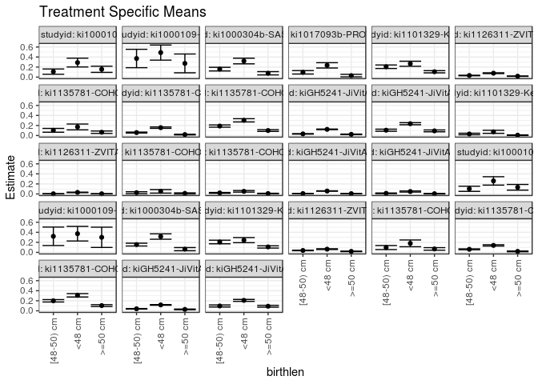

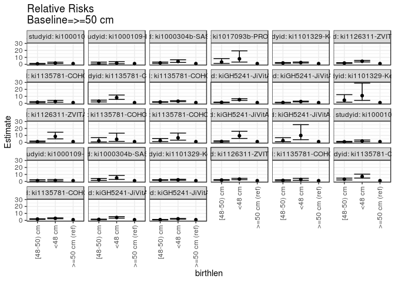

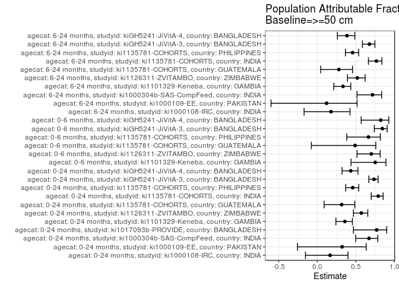

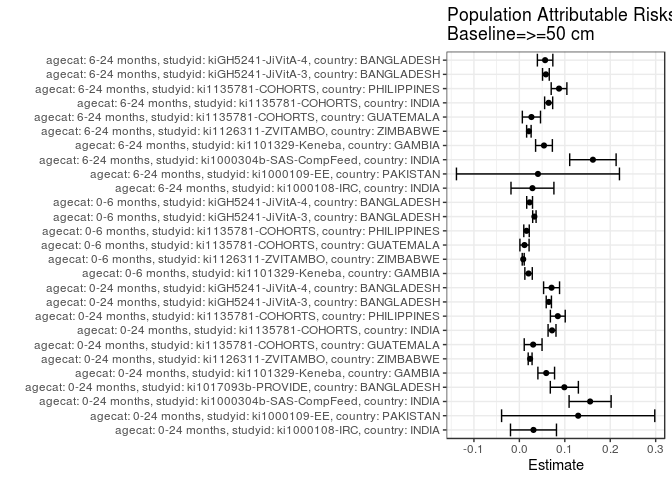

## Results Table

### Parameter: TSM

| agecat | studyid | country | intervention_level | baseline_level | estimate | ci_lower | ci_upper |
| --- | --- | --- | --- | --- | --- | --- | --- |
| 0-24 months | ki1000108-IRC | INDIA | >=50 cm | NA | 0.1556297 | 0.0941693 | 0.2170900 |
| 0-24 months | ki1000108-IRC | INDIA | <48 cm | NA | 0.2896357 | 0.2019323 | 0.3773392 |
| 0-24 months | ki1000108-IRC | INDIA | [48-50) cm | NA | 0.1086658 | 0.0561767 | 0.1611549 |
| 0-24 months | ki1000109-EE | PAKISTAN | >=50 cm | NA | 0.2727273 | 0.0856061 | 0.4598484 |
| 0-24 months | ki1000109-EE | PAKISTAN | <48 cm | NA | 0.4883721 | 0.3381480 | 0.6385962 |
| 0-24 months | ki1000109-EE | PAKISTAN | [48-50) cm | NA | 0.3703704 | 0.1872232 | 0.5535175 |
| 0-24 months | ki1000304b-SAS-CompFeed | INDIA | >=50 cm | NA | 0.0762973 | 0.0438559 | 0.1087387 |
| 0-24 months | ki1000304b-SAS-CompFeed | INDIA | <48 cm | NA | 0.3203675 | 0.2639052 | 0.3768298 |
| 0-24 months | ki1000304b-SAS-CompFeed | INDIA | [48-50) cm | NA | 0.1585770 | 0.1223309 | 0.1948231 |
| 0-24 months | ki1017093b-PROVIDE | BANGLADESH | >=50 cm | NA | 0.0295858 | 0.0040214 | 0.0551502 |
| 0-24 months | ki1017093b-PROVIDE | BANGLADESH | <48 cm | NA | 0.2338710 | 0.1811514 | 0.2865905 |
| 0-24 months | ki1017093b-PROVIDE | BANGLADESH | [48-50) cm | NA | 0.0954064 | 0.0611548 | 0.1296580 |
| 0-24 months | ki1101329-Keneba | GAMBIA | >=50 cm | NA | 0.1065755 | 0.0845467 | 0.1286043 |
| 0-24 months | ki1101329-Keneba | GAMBIA | <48 cm | NA | 0.2658897 | 0.2156742 | 0.3161051 |
| 0-24 months | ki1101329-Keneba | GAMBIA | [48-50) cm | NA | 0.2061237 | 0.1707739 | 0.2414736 |
| 0-24 months | ki1126311-ZVITAMBO | ZIMBABWE | >=50 cm | NA | 0.0177565 | 0.0136499 | 0.0218631 |
| 0-24 months | ki1126311-ZVITAMBO | ZIMBABWE | <48 cm | NA | 0.0775970 | 0.0695972 | 0.0855969 |
| 0-24 months | ki1126311-ZVITAMBO | ZIMBABWE | [48-50) cm | NA | 0.0319129 | 0.0271667 | 0.0366591 |
| 0-24 months | ki1135781-COHORTS | GUATEMALA | >=50 cm | NA | 0.0657275 | 0.0418792 | 0.0895759 |
| 0-24 months | ki1135781-COHORTS | GUATEMALA | <48 cm | NA | 0.1713000 | 0.1132857 | 0.2293144 |
| 0-24 months | ki1135781-COHORTS | GUATEMALA | [48-50) cm | NA | 0.1034850 | 0.0657502 | 0.1412199 |
| 0-24 months | ki1135781-COHORTS | INDIA | >=50 cm | NA | 0.0190906 | 0.0120435 | 0.0261378 |
| 0-24 months | ki1135781-COHORTS | INDIA | <48 cm | NA | 0.1564653 | 0.1429257 | 0.1700050 |
| 0-24 months | ki1135781-COHORTS | INDIA | [48-50) cm | NA | 0.0584944 | 0.0491098 | 0.0678790 |
| 0-24 months | ki1135781-COHORTS | PHILIPPINES | >=50 cm | NA | 0.0994648 | 0.0819334 | 0.1169962 |
| 0-24 months | ki1135781-COHORTS | PHILIPPINES | <48 cm | NA | 0.3031515 | 0.2708266 | 0.3354764 |
| 0-24 months | ki1135781-COHORTS | PHILIPPINES | [48-50) cm | NA | 0.1883851 | 0.1659298 | 0.2108404 |
| 0-24 months | kiGH5241-JiVitA-3 | BANGLADESH | >=50 cm | NA | 0.0233621 | 0.0179185 | 0.0288056 |
| 0-24 months | kiGH5241-JiVitA-3 | BANGLADESH | <48 cm | NA | 0.1229675 | 0.1173863 | 0.1285487 |
| 0-24 months | kiGH5241-JiVitA-3 | BANGLADESH | [48-50) cm | NA | 0.0325413 | 0.0279349 | 0.0371477 |

[output cut: 51 more lines]

### Parameter: E(Y)

| agecat | studyid | country | intervention_level | baseline_level | estimate | ci_lower | ci_upper |
| --- | --- | --- | --- | --- | --- | --- | --- |
| 0-24 months | ki1000108-IRC | INDIA | NA | NA | 0.1867008 | 0.1480272 | 0.2253743 |
| 0-24 months | ki1000109-EE | PAKISTAN | NA | NA | 0.4021739 | 0.3014293 | 0.5029185 |
| 0-24 months | ki1000304b-SAS-CompFeed | INDIA | NA | NA | 0.2320000 | 0.1911686 | 0.2728314 |
| 0-24 months | ki1017093b-PROVIDE | BANGLADESH | NA | NA | 0.1285714 | 0.1037574 | 0.1533855 |
| 0-24 months | ki1101329-Keneba | GAMBIA | NA | NA | 0.1656995 | 0.1471896 | 0.1842095 |
| 0-24 months | ki1126311-ZVITAMBO | ZIMBABWE | NA | NA | 0.0414553 | 0.0381291 | 0.0447815 |
| 0-24 months | ki1135781-COHORTS | GUATEMALA | NA | NA | 0.0960384 | 0.0760175 | 0.1160593 |
| 0-24 months | ki1135781-COHORTS | INDIA | NA | NA | 0.0909777 | 0.0840539 | 0.0979015 |
| 0-24 months | ki1135781-COHORTS | PHILIPPINES | NA | NA | 0.1840632 | 0.1702782 | 0.1978483 |
| 0-24 months | kiGH5241-JiVitA-3 | BANGLADESH | NA | NA | 0.0882064 | 0.0843238 | 0.0920889 |
| 0-24 months | kiGH5241-JiVitA-4 | BANGLADESH | NA | NA | 0.1635066 | 0.1508784 | 0.1761348 |
| 0-6 months | ki1101329-Keneba | GAMBIA | NA | NA | 0.0269382 | 0.0188017 | 0.0350748 |
| 0-6 months | ki1126311-ZVITAMBO | ZIMBABWE | NA | NA | 0.0120991 | 0.0102697 | 0.0139286 |
| 0-6 months | ki1135781-COHORTS | GUATEMALA | NA | NA | 0.0230583 | 0.0128042 | 0.0333123 |
| 0-6 months | ki1135781-COHORTS | PHILIPPINES | NA | NA | 0.0237154 | 0.0183020 | 0.0291288 |
| 0-6 months | kiGH5241-JiVitA-3 | BANGLADESH | NA | NA | 0.0391815 | 0.0366710 | 0.0416921 |
| 0-6 months | kiGH5241-JiVitA-4 | BANGLADESH | NA | NA | 0.0274281 | 0.0217023 | 0.0331538 |
| 6-24 months | ki1000108-IRC | INDIA | NA | NA | 0.1611253 | 0.1246376 | 0.1976130 |
| 6-24 months | ki1000109-EE | PAKISTAN | NA | NA | 0.3409091 | 0.2413043 | 0.4405139 |
| 6-24 months | ki1000304b-SAS-CompFeed | INDIA | NA | NA | 0.2260174 | 0.1899444 | 0.2620905 |
| 6-24 months | ki1101329-Keneba | GAMBIA | NA | NA | 0.1627438 | 0.1439757 | 0.1815119 |
| 6-24 months | ki1126311-ZVITAMBO | ZIMBABWE | NA | NA | 0.0403066 | 0.0365568 | 0.0440563 |
| 6-24 months | ki1135781-COHORTS | GUATEMALA | NA | NA | 0.0950413 | 0.0736937 | 0.1163890 |
| 6-24 months | ki1135781-COHORTS | INDIA | NA | NA | 0.0841713 | 0.0772407 | 0.0911019 |
| 6-24 months | ki1135781-COHORTS | PHILIPPINES | NA | NA | 0.1910032 | 0.1764432 | 0.2055633 |
| 6-24 months | kiGH5241-JiVitA-3 | BANGLADESH | NA | NA | 0.0863564 | 0.0817075 | 0.0910053 |
| 6-24 months | kiGH5241-JiVitA-4 | BANGLADESH | NA | NA | 0.1475190 | 0.1356672 | 0.1593708 |

### Parameter: RR

| agecat | studyid | country | intervention_level | baseline_level | estimate | ci_lower | ci_upper |
| --- | --- | --- | --- | --- | --- | --- | --- |
| 0-24 months | ki1000108-IRC | INDIA | >=50 cm | >=50 cm | 1.0000000 | 1.0000000 | 1.000000 |
| 0-24 months | ki1000108-IRC | INDIA | <48 cm | >=50 cm | 1.8610573 | 1.1332619 | 3.056252 |
| 0-24 months | ki1000108-IRC | INDIA | [48-50) cm | >=50 cm | 0.6982332 | 0.3738403 | 1.304112 |
| 0-24 months | ki1000109-EE | PAKISTAN | >=50 cm | >=50 cm | 1.0000000 | 1.0000000 | 1.000000 |
| 0-24 months | ki1000109-EE | PAKISTAN | <48 cm | >=50 cm | 1.7906977 | 0.8442525 | 3.798151 |
| 0-24 months | ki1000109-EE | PAKISTAN | [48-50) cm | >=50 cm | 1.3580247 | 0.5829181 | 3.163791 |
| 0-24 months | ki1000304b-SAS-CompFeed | INDIA | >=50 cm | >=50 cm | 1.0000000 | 1.0000000 | 1.000000 |
| 0-24 months | ki1000304b-SAS-CompFeed | INDIA | <48 cm | >=50 cm | 4.1989351 | 2.6872607 | 6.560977 |
| 0-24 months | ki1000304b-SAS-CompFeed | INDIA | [48-50) cm | >=50 cm | 2.0784087 | 1.3448032 | 3.212204 |
| 0-24 months | ki1017093b-PROVIDE | BANGLADESH | >=50 cm | >=50 cm | 1.0000000 | 1.0000000 | 1.000000 |
| 0-24 months | ki1017093b-PROVIDE | BANGLADESH | <48 cm | >=50 cm | 7.9048387 | 3.2364549 | 19.307074 |
| 0-24 months | ki1017093b-PROVIDE | BANGLADESH | [48-50) cm | >=50 cm | 3.2247350 | 1.2651132 | 8.219751 |
| 0-24 months | ki1101329-Keneba | GAMBIA | >=50 cm | >=50 cm | 1.0000000 | 1.0000000 | 1.000000 |
| 0-24 months | ki1101329-Keneba | GAMBIA | <48 cm | >=50 cm | 2.4948486 | 1.8880286 | 3.296703 |
| 0-24 months | ki1101329-Keneba | GAMBIA | [48-50) cm | >=50 cm | 1.9340636 | 1.4809357 | 2.525837 |
| 0-24 months | ki1126311-ZVITAMBO | ZIMBABWE | >=50 cm | >=50 cm | 1.0000000 | 1.0000000 | 1.000000 |
| 0-24 months | ki1126311-ZVITAMBO | ZIMBABWE | <48 cm | >=50 cm | 4.3700617 | 3.3927810 | 5.628845 |
| 0-24 months | ki1126311-ZVITAMBO | ZIMBABWE | [48-50) cm | >=50 cm | 1.7972521 | 1.3652537 | 2.365945 |
| 0-24 months | ki1135781-COHORTS | GUATEMALA | >=50 cm | >=50 cm | 1.0000000 | 1.0000000 | 1.000000 |
| 0-24 months | ki1135781-COHORTS | GUATEMALA | <48 cm | >=50 cm | 2.6062138 | 1.5887344 | 4.275322 |
| 0-24 months | ki1135781-COHORTS | GUATEMALA | [48-50) cm | >=50 cm | 1.5744545 | 0.9414538 | 2.633063 |
| 0-24 months | ki1135781-COHORTS | INDIA | >=50 cm | >=50 cm | 1.0000000 | 1.0000000 | 1.000000 |
| 0-24 months | ki1135781-COHORTS | INDIA | <48 cm | >=50 cm | 8.1959265 | 5.6117105 | 11.970185 |
| 0-24 months | ki1135781-COHORTS | INDIA | [48-50) cm | >=50 cm | 3.0640394 | 2.0497267 | 4.580288 |
| 0-24 months | ki1135781-COHORTS | PHILIPPINES | >=50 cm | >=50 cm | 1.0000000 | 1.0000000 | 1.000000 |
| 0-24 months | ki1135781-COHORTS | PHILIPPINES | <48 cm | >=50 cm | 3.0478278 | 2.4813985 | 3.743556 |
| 0-24 months | ki1135781-COHORTS | PHILIPPINES | [48-50) cm | >=50 cm | 1.8939878 | 1.5317611 | 2.341873 |
| 0-24 months | kiGH5241-JiVitA-3 | BANGLADESH | >=50 cm | >=50 cm | 1.0000000 | 1.0000000 | 1.000000 |
| 0-24 months | kiGH5241-JiVitA-3 | BANGLADESH | <48 cm | >=50 cm | 5.2635550 | 4.1528123 | 6.671385 |
| 0-24 months | kiGH5241-JiVitA-3 | BANGLADESH | [48-50) cm | >=50 cm | 1.3929122 | 1.0913987 | 1.777723 |

[output cut: 51 more lines]

### Parameter: PAR

| agecat | studyid | country | intervention_level | baseline_level | estimate | ci_lower | ci_upper |
| --- | --- | --- | --- | --- | --- | --- | --- |
| 0-24 months | ki1000108-IRC | INDIA | >=50 cm | NA | 0.0310711 | -0.0195263 | 0.0816685 |
| 0-24 months | ki1000109-EE | PAKISTAN | >=50 cm | NA | 0.1294466 | -0.0391292 | 0.2980225 |
| 0-24 months | ki1000304b-SAS-CompFeed | INDIA | >=50 cm | NA | 0.1557027 | 0.1094556 | 0.2019498 |
| 0-24 months | ki1017093b-PROVIDE | BANGLADESH | >=50 cm | NA | 0.0989856 | 0.0681034 | 0.1298678 |
| 0-24 months | ki1101329-Keneba | GAMBIA | >=50 cm | NA | 0.0591241 | 0.0407821 | 0.0774661 |
| 0-24 months | ki1126311-ZVITAMBO | ZIMBABWE | >=50 cm | NA | 0.0236988 | 0.0194525 | 0.0279451 |
| 0-24 months | ki1135781-COHORTS | GUATEMALA | >=50 cm | NA | 0.0303109 | 0.0107067 | 0.0499151 |
| 0-24 months | ki1135781-COHORTS | INDIA | >=50 cm | NA | 0.0718871 | 0.0631819 | 0.0805922 |
| 0-24 months | ki1135781-COHORTS | PHILIPPINES | >=50 cm | NA | 0.0845985 | 0.0682818 | 0.1009151 |
| 0-24 months | kiGH5241-JiVitA-3 | BANGLADESH | >=50 cm | NA | 0.0648443 | 0.0590983 | 0.0705903 |
| 0-24 months | kiGH5241-JiVitA-4 | BANGLADESH | >=50 cm | NA | 0.0708848 | 0.0533290 | 0.0884406 |
| 0-6 months | ki1101329-Keneba | GAMBIA | >=50 cm | NA | 0.0202448 | 0.0120697 | 0.0284199 |
| 0-6 months | ki1126311-ZVITAMBO | ZIMBABWE | >=50 cm | NA | 0.0084786 | 0.0063144 | 0.0106428 |
| 0-6 months | ki1135781-COHORTS | GUATEMALA | >=50 cm | NA | 0.0112935 | 0.0012027 | 0.0213844 |
| 0-6 months | ki1135781-COHORTS | PHILIPPINES | >=50 cm | NA | 0.0157367 | 0.0097173 | 0.0217561 |
| 0-6 months | kiGH5241-JiVitA-3 | BANGLADESH | >=50 cm | NA | 0.0330445 | 0.0292927 | 0.0367963 |
| 0-6 months | kiGH5241-JiVitA-4 | BANGLADESH | >=50 cm | NA | 0.0225540 | 0.0161589 | 0.0289490 |
| 6-24 months | ki1000108-IRC | INDIA | >=50 cm | NA | 0.0288001 | -0.0184267 | 0.0760270 |
| 6-24 months | ki1000109-EE | PAKISTAN | >=50 cm | NA | 0.0409091 | -0.1384651 | 0.2202833 |
| 6-24 months | ki1000304b-SAS-CompFeed | INDIA | >=50 cm | NA | 0.1618488 | 0.1107658 | 0.2129319 |
| 6-24 months | ki1101329-Keneba | GAMBIA | >=50 cm | NA | 0.0541835 | 0.0357267 | 0.0726403 |
| 6-24 months | ki1126311-ZVITAMBO | ZIMBABWE | >=50 cm | NA | 0.0209267 | 0.0159877 | 0.0258657 |
| 6-24 months | ki1135781-COHORTS | GUATEMALA | >=50 cm | NA | 0.0265444 | 0.0065448 | 0.0465440 |
| 6-24 months | ki1135781-COHORTS | INDIA | >=50 cm | NA | 0.0644583 | 0.0555930 | 0.0733236 |
| 6-24 months | ki1135781-COHORTS | PHILIPPINES | >=50 cm | NA | 0.0873081 | 0.0700487 | 0.1045675 |
| 6-24 months | kiGH5241-JiVitA-3 | BANGLADESH | >=50 cm | NA | 0.0583845 | 0.0509911 | 0.0657778 |
| 6-24 months | kiGH5241-JiVitA-4 | BANGLADESH | >=50 cm | NA | 0.0566544 | 0.0396531 | 0.0736557 |

### Parameter: PAF

| agecat | studyid | country | intervention_level | baseline_level | estimate | ci_lower | ci_upper |
| --- | --- | --- | --- | --- | --- | --- | --- |
| 0-24 months | ki1000108-IRC | INDIA | >=50 cm | NA | 0.1664219 | -0.1534698 | 0.3975981 |
| 0-24 months | ki1000109-EE | PAKISTAN | >=50 cm | NA | 0.3218673 | -0.2569606 | 0.6341461 |
| 0-24 months | ki1000304b-SAS-CompFeed | INDIA | >=50 cm | NA | 0.6711322 | 0.4979578 | 0.7845719 |
| 0-24 months | ki1017093b-PROVIDE | BANGLADESH | >=50 cm | NA | 0.7698882 | 0.4684627 | 0.9003806 |
| 0-24 months | ki1101329-Keneba | GAMBIA | >=50 cm | NA | 0.3568150 | 0.2410931 | 0.4548910 |
| 0-24 months | ki1126311-ZVITAMBO | ZIMBABWE | >=50 cm | NA | 0.5716709 | 0.4686162 | 0.6547395 |
| 0-24 months | ki1135781-COHORTS | GUATEMALA | >=50 cm | NA | 0.3156119 | 0.0880661 | 0.4863804 |
| 0-24 months | ki1135781-COHORTS | INDIA | >=50 cm | NA | 0.7901615 | 0.6992766 | 0.8535791 |
| 0-24 months | ki1135781-COHORTS | PHILIPPINES | >=50 cm | NA | 0.4596163 | 0.3689653 | 0.5372448 |
| 0-24 months | kiGH5241-JiVitA-3 | BANGLADESH | >=50 cm | NA | 0.7351431 | 0.6683636 | 0.7884756 |
| 0-24 months | kiGH5241-JiVitA-4 | BANGLADESH | >=50 cm | NA | 0.4335288 | 0.3209816 | 0.5274213 |
| 0-6 months | ki1101329-Keneba | GAMBIA | >=50 cm | NA | 0.7515264 | 0.4371398 | 0.8903118 |
| 0-6 months | ki1126311-ZVITAMBO | ZIMBABWE | >=50 cm | NA | 0.7007613 | 0.5151660 | 0.8153104 |
| 0-6 months | ki1135781-COHORTS | GUATEMALA | >=50 cm | NA | 0.4897833 | -0.0767738 | 0.7582398 |
| 0-6 months | ki1135781-COHORTS | PHILIPPINES | >=50 cm | NA | 0.6635638 | 0.3819918 | 0.8168482 |
| 0-6 months | kiGH5241-JiVitA-3 | BANGLADESH | >=50 cm | NA | 0.8433701 | 0.7395716 | 0.9057978 |
| 0-6 months | kiGH5241-JiVitA-4 | BANGLADESH | >=50 cm | NA | 0.8222956 | 0.5691586 | 0.9267042 |
| 6-24 months | ki1000108-IRC | INDIA | >=50 cm | NA | 0.1787437 | -0.1713024 | 0.4241779 |
| 6-24 months | ki1000109-EE | PAKISTAN | >=50 cm | NA | 0.1200000 | -0.5999326 | 0.5159796 |
| 6-24 months | ki1000304b-SAS-CompFeed | INDIA | >=50 cm | NA | 0.7160899 | 0.5143999 | 0.8340097 |
| 6-24 months | ki1101329-Keneba | GAMBIA | >=50 cm | NA | 0.3329376 | 0.2136476 | 0.4341312 |
| 6-24 months | ki1126311-ZVITAMBO | ZIMBABWE | >=50 cm | NA | 0.5191893 | 0.3910600 | 0.6203584 |
| 6-24 months | ki1135781-COHORTS | GUATEMALA | >=50 cm | NA | 0.2792930 | 0.0441117 | 0.4566116 |
| 6-24 months | ki1135781-COHORTS | INDIA | >=50 cm | NA | 0.7657996 | 0.6626505 | 0.8374094 |
| 6-24 months | ki1135781-COHORTS | PHILIPPINES | >=50 cm | NA | 0.4571027 | 0.3644010 | 0.5362839 |
| 6-24 months | kiGH5241-JiVitA-3 | BANGLADESH | >=50 cm | NA | 0.6760872 | 0.5854294 | 0.7469202 |
| 6-24 months | kiGH5241-JiVitA-4 | BANGLADESH | >=50 cm | NA | 0.3840483 | 0.2609766 | 0.4866245 |